# Project

```
array([[<matplotlib.axes._subplots.AxesSubplot object at 0x2b4ddfbcf908>]], dtype=object)
```

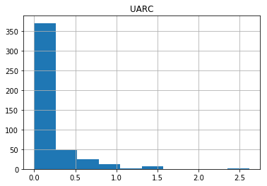

```python
pdf.hist(column='UARC')
```

Array is created from the spark dataframe to parse easily and improve performance.

```python
import numpy as np
data_array =  np.array(df_data_2.select("NARC","RARC","UARC").collect())
```

label array is created based on the following rules which will be used in our Random Forest Classifier

```python
labels = []
for elem in data_array:
    for i in elem:
        arr = []
        if(i < 0.15):
            arr.append('BadImprovement')
        elif(i >0.15 and i<1):
            arr.append('AvgImprovement')
        else:
            arr.append('GoodImprovement')
    labels.append(arr)
```

The training dataset is prepared using 70% of the datasets X_train

```python
from sklearn.model_selection import train_test_split
X_train, X_test, y_train, y_test  = train_test_split(data_array, labels, train_size=0.7, random_state=1234)

from sklearn.ensemble import RandomForestClassifier

#Create a Gaussian Classifier
clf=RandomForestClassifier(n_estimators=200)

#Train the model using the training sets y_pred=clf.predict(X_test)
clf.fit(X_train,y_train)

y_pred=clf.predict(X_test)
```

After training testing is performed using X_test dataset

```python
X_test
```

```
array([[ 0.23      ,  0.        ,  0.        ],
       [ 0.        ,  0.        ,  0.        ],
       [ 0.08      ,  0.16      ,  0.03      ],
       [ 0.09      ,  0.        ,  0.09      ],
       [ 0.14      ,  0.61000001,  0.02      ],
       [ 0.04      ,  0.13      ,  0.01      ],
       [ 0.64999998,  0.75999999,  0.33000001],
       [ 0.03      ,  0.        ,  0.        ],
       [ 0.07      ,  0.13      ,  0.06      ],
       [ 0.        ,  0.        ,  0.        ],
       [ 1.09000003,  0.87      ,  0.76999998],
       [ 0.        ,  0.        ,  0.        ],
       [ 0.01      ,  0.01      ,  0.09      ],
       [ 0.        ,  0.        ,  0.        ],
       [ 0.06      ,  0.12      ,  0.07      ],
       [ 0.        ,  0.        ,  0.        ],
       [ 0.        ,  0.        ,  0.        ],
       [ 0.33000001,  0.54000002,  0.20999999],
       [ 0.07      ,  0.        ,  0.        ],
       [ 0.55000001,  0.70999998,  0.18000001],
       [ 0.46000001,  0.61000001,  0.18000001],
       [ 0.        ,  0.        ,  0.        ],
       [ 0.02      ,  0.        ,  0.        ],
       [ 0.        ,  0.        ,  0.        ],
       [ 0.        ,  0.        ,  0.        ],
       [ 1.5       ,  1.49000001,  1.38999999],
       [ 1.        ,  1.12      ,  0.54000002],
       [ 0.        ,  0.        ,  0.        ],
       [ 0.51999998,  0.        ,  0.        ],
       [ 0.27000001,  0.34999999,  0.02      ],
       [ 0.85000002,  0.83999997,  0.47999999],
       [ 1.11000001,  1.49000001,  0.02      ],
       [ 0.31      ,  0.57999998,  0.06      ],
       [ 0.07      ,  0.03      ,  0.16      ],
       [ 0.2       ,  0.        ,  0.        ],
       [ 0.09      ,  0.08      ,  0.09      ],
       [ 0.07      ,  0.2       ,  0.03      ],
       [ 0.        ,  0.        ,  0.        ],
       [ 0.06      ,  0.18000001,  0.01      ],
       [ 0.93000001,  0.60000002,  0.86000001],
```

[output cut: 85 more lines]

```
       [ 0.86000001,  0.76999998,  0.61000001],
       [ 0.67000002,  0.56      ,  0.27000001],
       [ 0.        ,  0.        ,  0.        ],
       [ 0.31999999,  1.84000003,  0.07      ],
       [ 0.        ,  0.        ,  0.        ],
       [ 0.51999998,  0.        ,  0.        ],
       [ 1.24000001,  1.05999994,  0.67000002],
       [ 1.66999996,  1.57000005,  1.14999998],
       [ 0.        ,  0.        ,  0.        ],
       [ 0.05      ,  0.        ,  0.        ],
       [ 0.03      ,  0.14      ,  0.41      ],
       [ 0.25      ,  0.54000002,  0.20999999],
       [ 0.        ,  0.        ,  0.        ],
       [ 0.        ,  0.        ,  0.        ],
       [ 0.        ,  0.        ,  0.        ]])
```

These are the testing labels

```python
y_test
```

```
[['BadImprovement'],
 ['BadImprovement'],
 ['BadImprovement'],
 ['BadImprovement'],
 ['BadImprovement'],
 ['BadImprovement'],
 ['AvgImprovement'],
 ['BadImprovement'],
 ['BadImprovement'],
 ['BadImprovement'],
 ['AvgImprovement'],
 ['BadImprovement'],
 ['BadImprovement'],
 ['BadImprovement'],
 ['BadImprovement'],
 ['BadImprovement'],
 ['BadImprovement'],
 ['AvgImprovement'],
 ['BadImprovement'],
 ['AvgImprovement'],
 ['AvgImprovement'],
 ['BadImprovement'],
 ['BadImprovement'],
 ['BadImprovement'],
 ['BadImprovement'],
 ['GoodImprovement'],
 ['AvgImprovement'],
 ['BadImprovement'],
 ['BadImprovement'],
 ['BadImprovement'],
 ['AvgImprovement'],
 ['BadImprovement'],
 ['BadImprovement'],
 ['AvgImprovement'],
 ['BadImprovement'],
 ['BadImprovement'],
 ['BadImprovement'],
 ['BadImprovement'],
 ['BadImprovement'],
 ['AvgImprovement'],
```

[output cut: 85 more lines]

```
 ['AvgImprovement'],
 ['AvgImprovement'],
 ['BadImprovement'],
 ['BadImprovement'],
 ['BadImprovement'],
 ['BadImprovement'],
 ['AvgImprovement'],
 ['GoodImprovement'],
 ['BadImprovement'],
 ['BadImprovement'],
 ['AvgImprovement'],
 ['AvgImprovement'],
 ['BadImprovement'],
 ['BadImprovement'],
 ['BadImprovement']]
```

Below are the predictions made by model

```python
y_pred
```

```
array(['BadImprovement', 'BadImprovement', 'BadImprovement',
       'BadImprovement', 'BadImprovement', 'BadImprovement',
       'AvgImprovement', 'BadImprovement', 'BadImprovement',
       'BadImprovement', 'AvgImprovement', 'BadImprovement',
       'BadImprovement', 'BadImprovement', 'BadImprovement',
       'BadImprovement', 'BadImprovement', 'AvgImprovement',
       'BadImprovement', 'AvgImprovement', 'AvgImprovement',
       'BadImprovement', 'BadImprovement', 'BadImprovement',
       'BadImprovement', 'GoodImprovement', 'AvgImprovement',
       'BadImprovement', 'BadImprovement', 'BadImprovement',
       'AvgImprovement', 'BadImprovement', 'BadImprovement',
       'AvgImprovement', 'BadImprovement', 'BadImprovement',
       'BadImprovement', 'BadImprovement', 'BadImprovement',
       'AvgImprovement', 'BadImprovement', 'BadImprovement',
       'BadImprovement', 'AvgImprovement', 'BadImprovement',
       'BadImprovement', 'BadImprovement', 'BadImprovement',
       'BadImprovement', 'BadImprovement', 'AvgImprovement',
       'AvgImprovement', 'AvgImprovement', 'BadImprovement',
       'AvgImprovement', 'AvgImprovement', 'AvgImprovement',
       'BadImprovement', 'AvgImprovement', 'BadImprovement',
       'BadImprovement', 'BadImprovement', 'AvgImprovement',
       'AvgImprovement', 'BadImprovement', 'BadImprovement',
       'BadImprovement', 'BadImprovement', 'AvgImprovement',
       'AvgImprovement', 'AvgImprovement', 'BadImprovement',
       'BadImprovement', 'AvgImprovement', 'BadImprovement',
       'AvgImprovement', 'BadImprovement', 'BadImprovement',
       'AvgImprovement', 'BadImprovement', 'AvgImprovement',
       'AvgImprovement', 'AvgImprovement', 'BadImprovement',
       'BadImprovement', 'AvgImprovement', 'BadImprovement',
       'BadImprovement', 'BadImprovement', 'BadImprovement',
       'BadImprovement', 'GoodImprovement', 'AvgImprovement',
       'BadImprovement', 'AvgImprovement', 'BadImprovement',
       'BadImprovement', 'BadImprovement', 'AvgImprovement',
       'AvgImprovement', 'AvgImprovement', 'BadImprovement',
       'BadImprovement', 'AvgImprovement', 'BadImprovement',
       'BadImprovement', 'GoodImprovement', 'AvgImprovement',
       'BadImprovement', 'BadImprovement', 'BadImprovement',
       'BadImprovement', 'BadImprovement', 'BadImprovement',
       'BadImprovement', 'BadImprovement', 'BadImprovement',
       'BadImprovement', 'BadImprovement', 'AvgImprovement',
       'BadImprovement', 'BadImprovement', 'BadImprovement',
       'BadImprovement', 'BadImprovement', 'AvgImprovement',
       'AvgImprovement', 'BadImprovement', 'BadImprovement',
       'BadImprovement', 'BadImprovement', 'AvgImprovement',
       'GoodImprovement', 'BadImprovement', 'BadImprovement',
       'AvgImprovement', 'AvgImprovement', 'BadImprovement',
       'BadImprovement', 'BadImprovement'],
      dtype='<U15')
```

Accuracy of the model is computed below which turns out to be ~98.6%

```python
from sklearn import metrics
# Model Accuracy, how often is the classifier correct
print("Accuracy:",metrics.accuracy_score(y_test, y_pred))
```

```
Accuracy: 0.985714285714
```

A confusion matrix is plotted using matplotlib

[figure not shown]

```python
from sklearn.metrics import confusion_matrix
import matplotlib.pyplot as plt
label = ['BadImprovement', 'AvgImprovement', 'GoodImprovement']
cm = confusion_matrix(y_test, y_pred)
fig = plt.figure()
ax = fig.add_subplot(111)
cax = ax.matshow(cm)
plt.title('Countries classified based on drinkingwater \n')
fig.colorbar(cax)
ax.set_xticklabels([''] + label)
ax.set_yticklabels([''] + label)
plt.xlabel('Predicted')
plt.ylabel('True')
plt.show()
```

```python
from sklearn.metrics import confusion_matrix
confusion_matrix(y_test, y_pred)
```

```
array([[40,  0,  0],
       [ 0, 94,  0],
       [ 2,  0,  4]])
```

Now,let's see top 5 countries in 2015 which have higher improvement in water facilites

```python
df_data_year=df_data_1.filter(df_data_1.Year=="2015").select("Name","NARC","RARC","UARC")
```

```python
sorted_df = df_data_year.sort(["NARC"],ascending=False)
```

```python
sorted_df.show()
```

```
+--------------------+----+----+-----+
|                Name|NARC|RARC| UARC|
+--------------------+----+----+-----+
|         Afghanistan|2.39|2.17| 2.62|
|Lao People's Demo...|2.31|2.42| 0.98|
|               Yemen|1.84| 2.2| 0.38|
|                Mali|1.67|1.57| 1.15|
|          Mozambique|1.67|1.68| 1.31|
|            Paraguay|1.59| 3.1| 0.37|
|            Cambodia| 1.5|1.49| 1.39|
|            Ethiopia|1.49|1.51| 0.37|
|             Nigeria|1.42|1.53| 0.53|
|             Somalia|1.29| 0.9| 1.44|
|        Sierra Leone|1.29|1.55| 0.59|
|             Morocco|1.26|2.16| 0.19|
|United Republic o...|1.24|1.06| 0.67|
|               China|1.22|2.02|00.19|
|            Mongolia|1.21|1.61| 0.27|
|                Togo|1.16|1.02| 0.81|
|          Tajikistan|1.13|1.53|00.01|
|              Bhutan|1.11|1.49| 0.02|
|       Guinea-Bissau|1.09|0.87| 0.77|
|          Mauritania|1.07|1.22| 0.32|
+--------------------+----+----+-----+
only showing top 20 rows
```

```python
sorted_pandas = sorted_df.toPandas()
sorted_pandas
```

|  | Name | NARC | RARC | UARC |
| --- | --- | --- | --- | --- |
| 0 | Afghanistan | 2.39 | 2.17 | 2.62 |
| 1 | Lao People's Democratic Republic | 2.31 | 2.42 | 0.98 |
| 2 | Yemen | 1.84 | 2.2 | 0.38 |
| 3 | Mali | 1.67 | 1.57 | 1.15 |
| 4 | Mozambique | 1.67 | 1.68 | 1.31 |
| 5 | Paraguay | 1.59 | 3.1 | 0.37 |
| 6 | Cambodia | 1.5 | 1.49 | 1.39 |
| 7 | Ethiopia | 1.49 | 1.51 | 0.37 |
| 8 | Nigeria | 1.42 | 1.53 | 0.53 |
| 9 | Somalia | 1.29 | 0.9 | 1.44 |
| 10 | Sierra Leone | 1.29 | 1.55 | 0.59 |
| 11 | Morocco | 1.26 | 2.16 | 0.19 |
| 12 | United Republic of Tanzania | 1.24 | 1.06 | 0.67 |
| 13 | China | 1.22 | 2.02 | 00.19 |
| 14 | Mongolia | 1.21 | 1.61 | 0.27 |
| 15 | Togo | 1.16 | 1.02 | 0.81 |
| 16 | Tajikistan | 1.13 | 1.53 | 00.01 |
| 17 | Bhutan | 1.11 | 1.49 | 0.02 |
| 18 | Guinea-Bissau | 1.09 | 0.87 | 0.77 |
| 19 | Mauritania | 1.07 | 1.22 | 0.32 |
| 20 | Malawi | 1.04 | 1.16 | 0.15 |
| 21 | Sudan | 1.03 | 1.09 | 0.85 |
| 22 | Swaziland | 1.03 | 1.22 | 0.54 |
| 23 | Indonesia | 1 | 1.12 | 0.54 |
| 24 | Solomon Islands | 01.08 | 01.46 | 0 |
| 25 | Micronesia (Federated States of) | 00.28 | 00.41 | 0.14 |
| 26 | Zimbabwe | 00.25 | 00.3 | 00.05 |
| 27 | Comoros | 00.18 | 00.44 | 0.47 |
| 28 | Montserrat | 00.16 | 0 | 0 |
| 29 | Malaysia | 00.11 | 00.47 | 00.04 |
| ... | ... | ... | ... | ... |
| 202 | Cayman Islands | 0 | 0 | 0 |
| 203 | Cyprus | 0 | 0 | 0 |
| 204 | French Polynesia | 0 | 0 | 0 |
| 205 | Luxembourg | 0 | 0 | 0 |
| 206 | Montenegro | 0 | 0 | 0 |
| 207 | Netherlands | 0 | 0 | 0 |
| 208 | Puerto Rico | 0 | 0 | 0 |
| 209 | Qatar | 0 | 0 | 0 |
| 210 | Saint Helena | 0 | 0 | 0 |
| 211 | Saint Pierre and Miquelon | 0 | 0 | 0 |
| 212 | San Marino | 0 | 0 | 0 |
| 213 | Singapore | 0 | 0 | 0 |
| 214 | Sint Maarten (Dutch part) | 0 | 0 | 0 |
| 215 | Slovakia | 0 | 0 | 0 |
| 216 | Spain | 0 | 0 | 0 |
| 217 | Brunei Darussalam | 0 | 0 | 0 |
| 218 | Caribbean Netherlands | 0 | 0 | 0 |
| 219 | Faroe Islands | 0 | 0 | 0 |
| 220 | Iceland | 0 | 0 | 0 |
| 221 | Malta | 0 | 0 | 0 |
| 222 | Marshall Islands | 0 | 0 | 0 |
| 223 | Mayotte | 0 | 0 | 0 |
| 224 | New Zealand | 0 | 0 | 0 |
| 225 | Norway | 0 | 0 | 0 |
| 226 | Oman | 0 | 0 | 0 |
| 227 | Poland | 0 | 0 | 0 |
| 228 | Saint Kitts and Nevis | 0 | 0 | 0 |
| 229 | Timor-Leste | 0 | 0 | 0 |
| 230 | United Kingdom | 0 | 0 | 0 |
| 231 | United States Virgin Islands | 0 | 0 | 0 |

232 rows × 4 columns

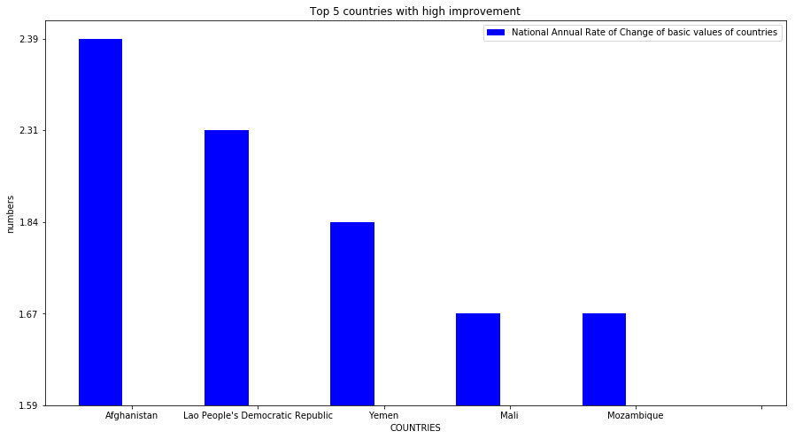

```python
%matplotlib inline
import matplotlib
import numpy as np
import matplotlib.pyplot as plt

ind=np.arange(6)
width = 0.35
bar = plt.bar(ind, sorted_pandas["NARC"][0:6], width, color='b', label = "National Annual Rate of Change of basic values of countries")

params = plt.gcf()
plSize = params.get_size_inches()
params.set_size_inches( (plSize[0]*2.5, plSize[1]*2) )
plt.ylabel('numbers')
plt.xlabel('COUNTRIES')
plt.title('Top 5 countries with high improvement')
plt.xticks(ind+width-0.1,sorted_pandas["Name"][0:5])
plt.legend()

plt.show()
```